# Power_analysis

Kianté Fernandez

9/8/2020

**Compute power for a One Factor ANOVA with seven levels**

```r
data %>%
  group_by(condition) %>%
  summarize(n = n(),
            mean = mean(Risk_Beta),
            sd = sd(Risk_Beta)) %>% na.omit() -> X
string <- "7b" #7 groups, one for each cog domain
n <- 45
# Say we are thinking of running 45 people in each condition (this is the average we currently gathered)
mu <- X$mean #extract the Risk_Beta means for each condition
# Enter means in the order that matches the labels below.
sd <- mean(X$sd) #use a single standard deviation to not break the assumption of equal variance
labelnames <- c("condition", "Attention (Concentration)", "Language (spoken)", "Long Term Memory", "Mood", "Motor Function", "Self-control", "Short Term (Working) Memory") #
# the label names should be in the order of the means specified above.
design_result <- ANOVA_design(design = string,
                   n = n,
                   mu = mu,
                   sd = sd,
                   labelnames = labelnames)
```

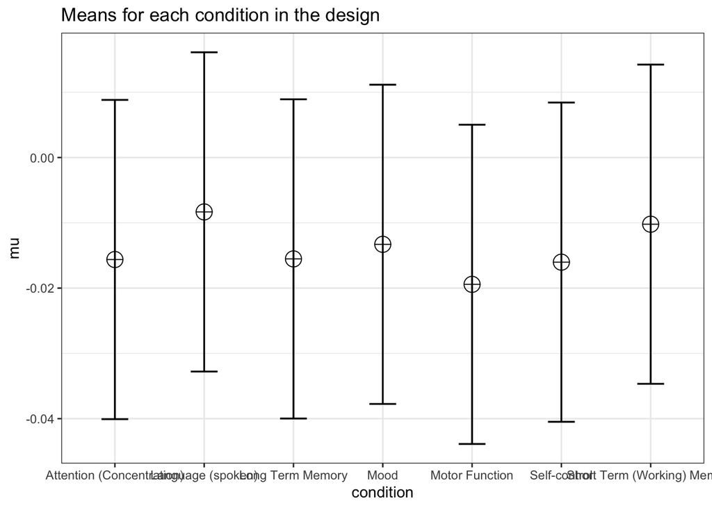

```r
alpha_level <- 0.05 #conventional

monte_result1 <- ANOVA_power(design_result,
                             alpha_level = 0.05,
                             verbose = FALSE,
                             emm = TRUE,
                             contrast_type = "pairwise",
                             emm_p_adjust = "holm", #mutiple comparisons adjust
                             nsims = 10000, #set total number of simulations
                             seed = 235353) #set seed for reproducibility

exact_result <- ANOVA_exact(design_result,
                            alpha_level = alpha_level,
                            verbose = FALSE)

knitr::kable(exact_result$main_results, caption = "Exact ANOVA Results")
```

Exact ANOVA Results

|  | power | partial_eta_squared | cohen_f | non_centrality |
| --- | --- | --- | --- | --- |
| condition | 69.51661 | 0.0352813 | 0.191237 | 11.26405 |

```r
knitr::kable(monte_result1$main_results, caption = "Simulated ANOVA Results")
```

Simulated ANOVA Results

|  | power | effect_size |
| --- | --- | --- |
| anova_condition | 69.69 | 0.0531566 |

```r
#showing it again with pwr package to check
K <- 7
n <- 45
f <- exact_result$main_results$cohen_f
pwr.anova.test(n = n,
               k = K,
               f = f,
               sig.level = alpha_level)$power
```

```
## [1] 0.7067759
```

Let’s explore which pattern of means we would need to expect to have 90% power for the ANOVA with 45 participants in each group.

```r
#now simulate a 90% power
K <- 7
n <- 45
sd <- mean(X$sd)
r <- 0
#Calculate f when running simulation
f <- pwr.anova.test(n = n,
                    k = K,
                    power = 0.9,
                    sig.level = alpha_level)$f
f
```

```
## [1] 0.2375491
```

```r
f2 <- f^2
ES <- f2 / (f2 + 1) #calcuate eta-squared
ES
```

```
## [1] 0.05341537
```

So, at least based on Cohen's benchmarks, we have 90% power to detect effects that are slightly below a medium effect benchmark (`f`). Expressed in eta-squared, we can detect values of `ES` or larger.

```r
#do a larger simulation with our posthoc data
```

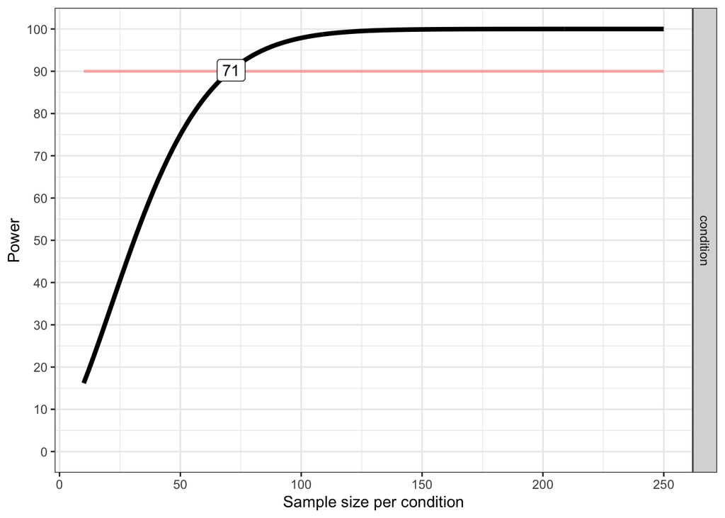

```
## Achieved Power and Sample Size for ANOVA-level effects
##    variable                  label  n achieved_power desired_power
## 1 condition Desired Power Achieved 71          90.24            90
```

```r
#calculate optimal n for 90% power given what we observed
plot_power(design_result, min_n = 10, max_n = 250)
```